# Assignment 3 - Random Forest + Boosting (Binary Classification)

```python
!pip install xgboost
```

```python
import pandas as pd
from sklearn.model_selection import train_test_split
from sklearn.ensemble import RandomForestClassifier
from sklearn.metrics import confusion_matrix, classification_report
from sklearn.metrics import roc_auc_score
import numpy as np
from sklearn.ensemble import AdaBoostClassifier
from sklearn.model_selection import GridSearchCV
from sklearn.ensemble import GradientBoostingClassifier
from xgboost import XGBClassifier
from sklearn.model_selection import RandomizedSearchCV
from sklearn.metrics import plot_roc_curve
import matplotlib.pyplot as plt
```

```python
df = pd.read_csv('https://archive.ics.uci.edu/ml/machine-learning-databases/adult/adult.data', header = None, skipinitialspace=True)
```

## Data Processing

```python
df.columns = ['age', 'workclass', 'fnlwgt', 'education', 'education_num', 'marital_status',
             'occupation', 'relationship', 'race', 'sex', 'capital_gain', 'captial_loss', 'hour_per_week',
              'native_country', 'salary']
```

```python
df.sample(5, random_state=42)
```

|  | age | workclass | fnlwgt | education | education_num | marital_status | occupation | relationship | race | sex | capital_gain | captial_loss | hour_per_week | native_country | salary |
| --- | --- | --- | --- | --- | --- | --- | --- | --- | --- | --- | --- | --- | --- | --- | --- |
| 14160 | 27 | Private | 160178 | Some-college | 10 | Divorced | Adm-clerical | Not-in-family | White | Female | 0 | 0 | 38 | United-States | <=50K |
| 27048 | 45 | State-gov | 50567 | HS-grad | 9 | Married-civ-spouse | Exec-managerial | Wife | White | Female | 0 | 0 | 40 | United-States | <=50K |
| 28868 | 29 | Private | 185908 | Bachelors | 13 | Married-civ-spouse | Exec-managerial | Husband | Black | Male | 0 | 0 | 55 | United-States | >50K |
| 5667 | 30 | Private | 190040 | Bachelors | 13 | Never-married | Machine-op-inspct | Not-in-family | White | Female | 0 | 0 | 40 | United-States | <=50K |
| 7827 | 29 | Self-emp-not-inc | 189346 | Some-college | 10 | Divorced | Craft-repair | Not-in-family | White | Male | 2202 | 0 | 50 | United-States | <=50K |

```python
df.shape
```

```
(32561, 15)
```

```python
df = df.drop('fnlwgt', axis = 1)
```

```python
df['salary'] = df['salary'].replace(['<=50K', '>50K'], [0, 1])
```

```python
X = df[['age', 'workclass', 'education', 'education_num', 'marital_status',
        'occupation', 'relationship', 'race', 'sex', 'capital_gain', 'captial_loss',
        'hour_per_week', 'native_country']]
y = df['salary']
```

```python
X_encoded = pd.get_dummies(X)
```

```python
X_encoded.shape
```

```
(32561, 107)
```

```python
X_train, X_test, y_train, y_test = train_test_split(X_encoded, y, test_size = 0.3, random_state = 42)
```

```python
X_train.shape
```

```
(22792, 107)
```

```python
X_test.shape
```

```
(9769, 107)
```

## Random Forest Classifier - Base Model

```python
rf = RandomForestClassifier(random_state = 42)
rf.fit(X_train, y_train)
```

```
RandomForestClassifier(random_state=42)
```

```python
y_pred = rf.predict(X_test)
y_pred_proba = rf.predict_proba(X_test)
```

```python
confusion_matrix(y_test, y_pred)
```

```
array([[6828,  627],
       [ 873, 1441]])
```

```python
print(classification_report(y_test, y_pred))
```

```
              precision    recall  f1-score   support

           0       0.89      0.92      0.90      7455
           1       0.70      0.62      0.66      2314

    accuracy                           0.85      9769
   macro avg       0.79      0.77      0.78      9769
weighted avg       0.84      0.85      0.84      9769
```

```python
new_y_pred_proba = y_pred_proba[:, 1]
auc = roc_auc_score(y_test, new_y_pred_proba)
auc
```

```
0.8889081826018049
```

```python
top5 = rf.feature_importances_
indices = np.argsort(top5)[::-1][:5]
print('\n'.join([f"{X_train.columns[i]}: {top5[i]}" for i in indices]))
```

```
age: 0.2206197918208295
hour_per_week: 0.11370445361634884
capital_gain: 0.09857230928798685
marital_status_Married-civ-spouse: 0.07508058198623269
education_num: 0.06734543681554647
```

```python
y_train_pred = rf.predict(X_train)
print(classification_report(y_train, y_train_pred))
```

```
              precision    recall  f1-score   support

           0       0.98      0.99      0.99     17265
           1       0.97      0.95      0.96      5527

    accuracy                           0.98     22792
   macro avg       0.98      0.97      0.97     22792
weighted avg       0.98      0.98      0.98     22792
```

## AdaBoost Classifier - GridSearch

```python
param_grid = {'n_estimators': [100, 200, 300, 400], 'learning_rate': [0.2,0.4,0.6,0.8,1,1.2]}
ada = AdaBoostClassifier()
ada_cv = GridSearchCV(ada, param_grid, scoring='roc_auc', cv=5)
ada_cv.fit(X_train, y_train)
```

```
GridSearchCV(cv=5, estimator=AdaBoostClassifier(),
             param_grid={'learning_rate': [0.2, 0.4, 0.6, 0.8, 1, 1.2],
                         'n_estimators': [100, 200, 300, 400]},
             scoring='roc_auc')
```

```python
best_ada = ada_cv.best_estimator_
y_pred_proba = best_ada.predict_proba(X_test)[:,1]
y_pred = best_ada.predict(X_test)
```

```python
confusion_matrix(y_test, y_pred)
```

```
array([[7008,  447],
       [ 807, 1507]])
```

```python
print(classification_report(y_test, y_pred))
```

```
              precision    recall  f1-score   support

           0       0.90      0.94      0.92      7455
           1       0.77      0.65      0.71      2314

    accuracy                           0.87      9769
   macro avg       0.83      0.80      0.81      9769
weighted avg       0.87      0.87      0.87      9769
```

```python
roc_auc_score(y_test, y_pred_proba)
```

```
0.9244122180504519
```

```python
feature_importances = pd.Series(best_ada.feature_importances_, index=X_train.columns)
top5 = feature_importances.sort_values(ascending=False)[:5]
```

```python
top5
```

```
capital_gain     0.3300
captial_loss     0.2900
age              0.1075
hour_per_week    0.0575
education_num    0.0100
dtype: float64
```

```python
y_train_pred = best_ada.predict(X_train)
print(classification_report(y_train, y_train_pred))
```

```
              precision    recall  f1-score   support

           0       0.90      0.94      0.92     17265
           1       0.78      0.66      0.71      5527

    accuracy                           0.87     22792
   macro avg       0.84      0.80      0.82     22792
weighted avg       0.87      0.87      0.87     22792
```

## Gradient Boosting Classifier - GridSearch

```python
param_grid = {'n_estimators': [100, 200, 300, 400], 'learning_rate': [0.1, 0.3, 0.5], 'max_depth': [1, 2]}

gbc = GradientBoostingClassifier(random_state=42)
grid_search = GridSearchCV(gbc, param_grid, scoring='roc_auc', cv=5)
grid_search.fit(X_train, y_train)
```

```
GridSearchCV(cv=5, estimator=GradientBoostingClassifier(random_state=42),
             param_grid={'learning_rate': [0.1, 0.3, 0.5], 'max_depth': [1, 2],
                         'n_estimators': [100, 200, 300, 400]},
             scoring='roc_auc')
```

```python
best_gbc = grid_search.best_estimator_

y_pred_proba = best_gbc.predict_proba(X_test)[:, 1]
y_pred = best_gbc.predict(X_test)
```

```python
confusion_matrix(y_test, y_pred)
```

```
array([[7017,  438],
       [ 796, 1518]])
```

```python
print(classification_report(y_test, y_pred))
```

```
              precision    recall  f1-score   support

           0       0.90      0.94      0.92      7455
           1       0.78      0.66      0.71      2314

    accuracy                           0.87      9769
   macro avg       0.84      0.80      0.82      9769
weighted avg       0.87      0.87      0.87      9769
```

```python
auc_score = roc_auc_score(y_test, y_pred_proba)
auc_score
```

```
0.9263378600615505
```

```python
top5 = best_gbc.feature_importances_
indices = np.argsort(top5)[::-1][:5]
print('\n'.join([f"{X_train.columns[i]}: {top5[i]}" for i in indices]))
```

```
marital_status_Married-civ-spouse: 0.36637248850531406
capital_gain: 0.2094199558127223
education_num: 0.16761395533099757
captial_loss: 0.06862102117133104
age: 0.06014655547058931
```

```python
y_pred_train = best_gbc.predict(X_train)
print(classification_report(y_train, y_pred_train))
```

```
              precision    recall  f1-score   support

           0       0.90      0.95      0.93     17265
           1       0.81      0.69      0.74      5527

    accuracy                           0.88     22792
   macro avg       0.86      0.82      0.83     22792
weighted avg       0.88      0.88      0.88     22792
```

## XGBoost - RandomizedSearchCV

```python
param_grid = {"n_estimators": np.arange(100, 1050, 50), "learning_rate": np.arange(0.1, 1.7, 0.1), "max_depth": [1, 2],"gamma": np.arange(0, 5.25, 0.25)}
xgb = XGBClassifier(random_state=42)
xgb_search = RandomizedSearchCV(estimator=xgb, param_distributions=param_grid, n_iter=100, scoring="roc_auc", cv=5, random_state=42)
xgb_search.fit(X_train, y_train)
```

```
RandomizedSearchCV(cv=5,
                   estimator=XGBClassifier(base_score=None, booster=None,
                                           callbacks=None,
                                           colsample_bylevel=None,
                                           colsample_bynode=None,
                                           colsample_bytree=None,
                                           early_stopping_rounds=None,
                                           enable_categorical=False,
                                           eval_metric=None, feature_types=None,
                                           gamma=None, gpu_id=None,
                                           grow_policy=None,
                                           importance_type=None,
                                           interaction_constraints=None,
                                           learning_rate...
                   param_distributions={'gamma': array([0.  , 0.25, 0.5 , 0.75, 1.  , 1.25, 1.5 , 1.75, 2.  , 2.25, 2.5 ,
       2.75, 3.  , 3.25, 3.5 , 3.75, 4.  , 4.25, 4.5 , 4.75, 5.  ]),
                                        'learning_rate': array([0.1, 0.2, 0.3, 0.4, 0.5, 0.6, 0.7, 0.8, 0.9, 1. , 1.1, 1.2, 1.3,
       1.4, 1.5, 1.6]),
                                        'max_depth': [1, 2],
                                        'n_estimators': array([ 100,  150,  200,  250,  300,  350,  400,  450,  500,  550,  600,
        650,  700,  750,  800,  850,  900,  950, 1000])},
                   random_state=42, scoring='roc_auc')
```

```python
print(f"Best parameters: {xgb_search.best_params_}")
```

```
Best parameters: {'n_estimators': 600, 'max_depth': 1, 'learning_rate': 1.3000000000000003, 'gamma': 0.0}
```

```python
print(f"Best score: {xgb_search.best_score_:.4f}")
```

```
Best score: 0.9283
```

```python
y_pred = xgb_search.best_estimator_.predict(X_test)
```

```python
y_pred_proba = xgb_search.best_estimator_.predict_proba(X_test)[:, 1]
```

```python
confusion_matrix(y_test, y_pred)
```

```
array([[7023,  432],
       [ 817, 1497]])
```

```python
print(classification_report(y_test, y_pred))
```

```
              precision    recall  f1-score   support

           0       0.90      0.94      0.92      7455
           1       0.78      0.65      0.71      2314

    accuracy                           0.87      9769
   macro avg       0.84      0.79      0.81      9769
weighted avg       0.87      0.87      0.87      9769
```

```python
auc_score = roc_auc_score(y_test, y_pred_proba)
auc_score
```

```
0.9258622898439325
```

```python
imp = pd.DataFrame({'Feature': X_train.columns, 'Importance': xgb_search.best_estimator_.feature_importances_})
imp.head(5)
```

|  | Feature | Importance |
| --- | --- | --- |
| 0 | age | 0.003794 |
| 1 | education_num | 0.057291 |
| 2 | capital_gain | 0.003044 |
| 3 | captial_loss | 0.001097 |
| 4 | hour_per_week | 0.003500 |

```python
y_pred_train = xgb_search.best_estimator_.predict(X_train)
print(classification_report(y_train, y_pred_train))
```

```
              precision    recall  f1-score   support

           0       0.90      0.94      0.92     17265
           1       0.79      0.66      0.72      5527

    accuracy                           0.88     22792
   macro avg       0.84      0.80      0.82     22792
weighted avg       0.87      0.88      0.87     22792
```

## Conceptual Problems

**a) The lecture notes describe the Gini Index which is the default criterion used for splitting in sklearn's version of RandomForestClassifier. How does the Gini Index work? (i.e. How is it used to build a top-performing model?).**

- The Gini Index measures the impurity of a node in a decision tree. A lower value of the Gini Index indicates a purer node. In this context, the algorithm builds a forest of decision trees, where each tree splits the data based on the feature that produces the lowest Gini Index.

**b) Describe how Random Forest is different from bagging & why this difference can yield improved results.**

- Random Forest introduces additional randomness in the construction of the trees by considering only a random subset of the features for each split. Thisreduces the correlation between the trees and can yield improved results.

**c) Describe the importance of the max_depth parameter in Random Forest. Do not just provide a definition, rather think through how bias-variance tradeoff might be impacted by the max_depth parameter.**

- The max_depth parameter in Random Forest determines the maximum depth of each decision tree in the forest. A lower max_depth value will result in simpler trees that may underfit the data, while a higher value may produce more complex trees that overfit. Therefore, the max_depth parameter affects the bias-variance tradeoff by controlling the level of model complexity.

**d)What does the alpha parameter represent in AdaBoost? Please refer to chapter 7 of the Hands-On ML book if you are struggling.**

- The alpha parameter determines the contribution of each model to the final prediction. It assigns a weight to each model based on its performance.

**e) In AdaBoost explain how the final predicted class is determined. Be sure to reference the alpha term in your explanation.**

- The final predicted class is determined by the weighted sum of the predictions of all the models in the ensemble, where the weights are the alpha values of each model.

**f) In Gradient Boosting, what is the role of the max_depth parameter? Why is it important to tune on this parameter?**

- Similar to RFC, the max_depth parameter determines the maximum depth of each decision tree in the ensemble. A lower max_depth value will result in simpler trees that may underfit the data, while a higher value may produce more complex trees that overfit.

**g) In Part (e) of Steps 2-5 you determined the top 5 predictors across each model. Do any predictors show up in the top 5 predictors for all three models? If so, comment on if this predictor makes sense given what you are attempting to predict. (Note: If you don't have any predictors showing up across all 3 predictors, explain one that shows up in 2 of them).**

- 'education_num' shows up in all three models. Education number does mkae sense given we're predicting salary. The more education years,the more likely it is for an individual to have higher paying jobs or qualify for more skilled positions that require specialized knowledge or training.

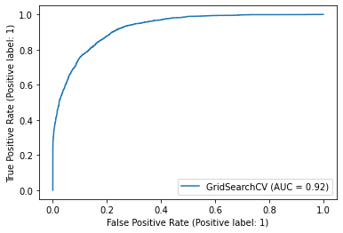

```python
plot_roc_curve(ada_cv, X_test, y_test)
plt.show()
```